# SALES ANALYSIS-PHYTON

```python
#importing necessary libraries
import pandas as pd

import matplotlib.pyplot as plt
%matplotlib inline

import seaborn as sns
```

```python
file = pd.read_csv(r'superstore_sales.csv', encoding='latin1')
file
```

|  | order_id | order_date | ship_date | ship_mode | customer_name | segment | state | country | market | region | product_id | category | sub_category | product_name | sales | quantity | discount | profit | shipping_cost | order_priority |
| --- | --- | --- | --- | --- | --- | --- | --- | --- | --- | --- | --- | --- | --- | --- | --- | --- | --- | --- | --- | --- |
| 0 | AG-2023-2040 | 1/1/2023 | 1/6/2023 | Standard Class | Toby Braunhardt | Consumer | Constantine | Algeria | Africa | Africa | OFF-TEN-10000025 | Office Supplies | Storage | Tenex Lockers, Blue | 408 | 2 | 0.0 | 106.1400 | 35.46 | Medium |
| 1 | IN-2023-47883 | 1/1/2023 | 1/8/2023 | Standard Class | Joseph Holt | Consumer | New South Wales | Australia | APAC | Oceania | OFF-SU-10000618 | Office Supplies | Supplies | Acme Trimmer, High Speed | 120 | 3 | 0.1 | 36.0360 | 9.72 | Medium |
| 2 | HU-2023-1220 | 1/1/2023 | 1/5/2023 | Second Class | Annie Thurman | Consumer | Budapest | Hungary | EMEA | EMEA | OFF-TEN-10001585 | Office Supplies | Storage | Tenex Box, Single Width | 66 | 4 | 0.0 | 29.6400 | 8.17 | High |
| 3 | IT-2023-3647632 | 1/1/2023 | 1/5/2023 | Second Class | Eugene Moren | Home Office | Stockholm | Sweden | EU | North | OFF-PA-10001492 | Office Supplies | Paper | Enermax Note Cards, Premium | 45 | 3 | 0.5 | -26.0550 | 4.82 | High |
| 4 | IN-2023-47883 | 1/1/2023 | 1/8/2023 | Standard Class | Joseph Holt | Consumer | New South Wales | Australia | APAC | Oceania | FUR-FU-10003447 | Furniture | Furnishings | Eldon Light Bulb, Duo Pack | 114 | 5 | 0.1 | 37.7700 | 4.70 | Medium |
| ... | ... | ... | ... | ... | ... | ... | ... | ... | ... | ... | ... | ... | ... | ... | ... | ... | ... | ... | ... | ... |
| 51285 | CA-2020-115427 | 12/31/2020 | 1/4/2021 | Standard Class | Erica Bern | Corporate | California | United States | US | West | OFF-BI-10002103 | Office Supplies | Binders | Cardinal Slant-D Ring Binder, Heavy Gauge Vinyl | 14 | 2 | 0.2 | 4.5188 | 0.89 | Medium |
| 51286 | MO-2020-2560 | 12/31/2020 | 1/5/2021 | Standard Class | Liz Preis | Consumer | Souss-Massa-Draâ | Morocco | Africa | Africa | OFF-WIL-10001069 | Office Supplies | Binders | Wilson Jones Hole Reinforcements, Clear | 4 | 1 | 0.0 | 0.4200 | 0.49 | Medium |
| 51287 | MX-2020-110527 | 12/31/2020 | 1/2/2021 | Second Class | Charlotte Melton | Consumer | Managua | Nicaragua | LATAM | Central | OFF-LA-10004182 | Office Supplies | Labels | Hon Color Coded Labels, 5000 Label Set | 26 | 3 | 0.0 | 12.3600 | 0.35 | Medium |
| 51288 | MX-2020-114783 | 12/31/2020 | 1/6/2021 | Standard Class | Tamara Dahlen | Consumer | Chihuahua | Mexico | LATAM | North | OFF-LA-10000413 | Office Supplies | Labels | Hon Legal Exhibit Labels, Alphabetical | 7 | 1 | 0.0 | 0.5600 | 0.20 | Medium |
| 51289 | CA-2020-156720 | 12/31/2020 | 1/4/2021 | Standard Class | Jill Matthias | Consumer | Colorado | United States | US | West | OFF-FA-10003472 | Office Supplies | Fasteners | Bagged Rubber Bands | 3 | 3 | 0.2 | -0.6048 | 0.17 | Medium |

51290 rows × 20 columns

```python
returns=pd.read_excel(r'sales_returns.xlsx')
returns
```

|  | Returned | Order ID | Market |
| --- | --- | --- | --- |
| 0 | Yes | MX-2021-168137 | LATAM |
| 1 | Yes | US-2023-165316 | LATAM |
| 2 | Yes | ES-2021-1525878 | EU |
| 3 | Yes | CA-2021-118311 | United States |
| 4 | Yes | ES-2023-1276768 | EU |
| ... | ... | ... | ... |
| 1168 | Yes | ES-2021-2639112 | EU |
| 1169 | Yes | CA-2020-134194 | United States |
| 1170 | Yes | ES-2022-3246286 | EU |
| 1171 | Yes | ES-2022-4379168 | EU |
| 1172 | Yes | CA-2020-168193 | United States |

1173 rows × 3 columns

```python
df = pd.merge(file, returns[['Order ID', 'Returned']], left_on='order_id', right_on='Order ID', how='left')
df
```

|  | order_id | order_date | ship_date | ship_mode | customer_name | segment | state | country | market | region | ... | sub_category | product_name | sales | quantity | discount | profit | shipping_cost | order_priority | Order ID | Returned |
| --- | --- | --- | --- | --- | --- | --- | --- | --- | --- | --- | --- | --- | --- | --- | --- | --- | --- | --- | --- | --- | --- |
| 0 | AG-2023-2040 | 1/1/2023 | 1/6/2023 | Standard Class | Toby Braunhardt | Consumer | Constantine | Algeria | Africa | Africa | ... | Storage | Tenex Lockers, Blue | 408 | 2 | 0.0 | 106.1400 | 35.46 | Medium | NaN | NaN |
| 1 | IN-2023-47883 | 1/1/2023 | 1/8/2023 | Standard Class | Joseph Holt | Consumer | New South Wales | Australia | APAC | Oceania | ... | Supplies | Acme Trimmer, High Speed | 120 | 3 | 0.1 | 36.0360 | 9.72 | Medium | NaN | NaN |
| 2 | HU-2023-1220 | 1/1/2023 | 1/5/2023 | Second Class | Annie Thurman | Consumer | Budapest | Hungary | EMEA | EMEA | ... | Storage | Tenex Box, Single Width | 66 | 4 | 0.0 | 29.6400 | 8.17 | High | NaN | NaN |
| 3 | IT-2023-3647632 | 1/1/2023 | 1/5/2023 | Second Class | Eugene Moren | Home Office | Stockholm | Sweden | EU | North | ... | Paper | Enermax Note Cards, Premium | 45 | 3 | 0.5 | -26.0550 | 4.82 | High | NaN | NaN |
| 4 | IN-2023-47883 | 1/1/2023 | 1/8/2023 | Standard Class | Joseph Holt | Consumer | New South Wales | Australia | APAC | Oceania | ... | Furnishings | Eldon Light Bulb, Duo Pack | 114 | 5 | 0.1 | 37.7700 | 4.70 | Medium | NaN | NaN |
| ... | ... | ... | ... | ... | ... | ... | ... | ... | ... | ... | ... | ... | ... | ... | ... | ... | ... | ... | ... | ... | ... |
| 51290 | CA-2020-115427 | 12/31/2020 | 1/4/2021 | Standard Class | Erica Bern | Corporate | California | United States | US | West | ... | Binders | Cardinal Slant-D Ring Binder, Heavy Gauge Vinyl | 14 | 2 | 0.2 | 4.5188 | 0.89 | Medium | CA-2020-115427 | Yes |
| 51291 | MO-2020-2560 | 12/31/2020 | 1/5/2021 | Standard Class | Liz Preis | Consumer | Souss-Massa-Draâ | Morocco | Africa | Africa | ... | Binders | Wilson Jones Hole Reinforcements, Clear | 4 | 1 | 0.0 | 0.4200 | 0.49 | Medium | NaN | NaN |
| 51292 | MX-2020-110527 | 12/31/2020 | 1/2/2021 | Second Class | Charlotte Melton | Consumer | Managua | Nicaragua | LATAM | Central | ... | Labels | Hon Color Coded Labels, 5000 Label Set | 26 | 3 | 0.0 | 12.3600 | 0.35 | Medium | NaN | NaN |
| 51293 | MX-2020-114783 | 12/31/2020 | 1/6/2021 | Standard Class | Tamara Dahlen | Consumer | Chihuahua | Mexico | LATAM | North | ... | Labels | Hon Legal Exhibit Labels, Alphabetical | 7 | 1 | 0.0 | 0.5600 | 0.20 | Medium | MX-2020-114783 | Yes |
| 51294 | CA-2020-156720 | 12/31/2020 | 1/4/2021 | Standard Class | Jill Matthias | Consumer | Colorado | United States | US | West | ... | Fasteners | Bagged Rubber Bands | 3 | 3 | 0.2 | -0.6048 | 0.17 | Medium | NaN | NaN |

51295 rows × 22 columns

```python
#replacing Nan in returned column with No

df['Returned'].fillna('No', inplace=True)
```

```python
# Drop the 'Order ID' column as it's no longer needed

df.drop(['Order ID','customer_name','order_priority'], axis=1, inplace=True)
```

```python
# checking for duplicates

df.duplicated().sum()
```

```
5
```

```python
#removing duplicates

df.drop_duplicates(inplace=True)
```

```python
#shape gives dimesnion of dataframe

df.shape
```

```
(51290, 19)
```

```python
#concise summary of dataframe

df.info()
```

```
<class 'pandas.core.frame.DataFrame'>
Index: 51290 entries, 0 to 51294
Data columns (total 19 columns):
 #   Column         Non-Null Count  Dtype
---  ------         --------------  -----
 0   order_id       51290 non-null  object
 1   order_date     51290 non-null  object
 2   ship_date      51290 non-null  object
 3   ship_mode      51290 non-null  object
 4   segment        51290 non-null  object
 5   state          51290 non-null  object
 6   country        51290 non-null  object
 7   market         51290 non-null  object
 8   region         51290 non-null  object
 9   product_id     51290 non-null  object
 10  category       51290 non-null  object
 11  sub_category   51290 non-null  object
 12  product_name   51290 non-null  object
 13  sales          51290 non-null  object
 14  quantity       51290 non-null  int64
 15  discount       51290 non-null  float64
 16  profit         51290 non-null  float64
 17  shipping_cost  51290 non-null  float64
 18  Returned       51290 non-null  object
dtypes: float64(3), int64(1), object(15)
memory usage: 7.8+ MB
```

Changing datatypes :

In the dataset, the 'Order Date' and 'Ship Date' are currently stored as object data types,change them to datetime. Additionally, the 'Sales' column, currently in object data type, should be converted to int.

```python
df['order_date'] = pd.to_datetime(df['order_date'])
df['ship_date'] = pd.to_datetime(df['ship_date'])

print('The datatype of order date is :',df['order_date'].dtypes)
print('The datatype of ship date is:', df['ship_date'].dtypes)
```

```
The datatype of order date is : datetime64[ns]
The datatype of ship date is: datetime64[ns]
```

AS we are getting error while converting it into int. The reason behind is that we have comma between the numbers.So removing the comma and changing it into int.

```python
# Remove commas from the 'sales' column and then convert to integer
df['sales'] = df['sales'].str.replace(',', '').astype(int)
```

```python
df['sales'] = df['sales'].astype('int64')
df.info()
```

```
<class 'pandas.core.frame.DataFrame'>
Index: 51290 entries, 0 to 51294
Data columns (total 19 columns):
 #   Column         Non-Null Count  Dtype
---  ------         --------------  -----
 0   order_id       51290 non-null  object
 1   order_date     51290 non-null  datetime64[ns]
 2   ship_date      51290 non-null  datetime64[ns]
 3   ship_mode      51290 non-null  object
 4   segment        51290 non-null  object
 5   state          51290 non-null  object
 6   country        51290 non-null  object
 7   market         51290 non-null  object
 8   region         51290 non-null  object
 9   product_id     51290 non-null  object
 10  category       51290 non-null  object
 11  sub_category   51290 non-null  object
 12  product_name   51290 non-null  object
 13  sales          51290 non-null  int64
 14  quantity       51290 non-null  int64
 15  discount       51290 non-null  float64
 16  profit         51290 non-null  float64
 17  shipping_cost  51290 non-null  float64
 18  Returned       51290 non-null  object
dtypes: datetime64[ns](2), float64(3), int64(2), object(12)
memory usage: 7.8+ MB
```

```python
#checking for total null values

df.isnull().sum()
```

```
order_id         0
order_date       0
ship_date        0
ship_mode        0
segment          0
state            0
country          0
market           0
region           0
product_id       0
category         0
sub_category     0
product_name     0
sales            0
quantity         0
discount         0
profit           0
shipping_cost    0
Returned         0
dtype: int64
```

```python
# give statistical summary of numerical columns by default

df.describe()
```

|  | order_date | ship_date | sales | quantity | discount | profit | shipping_cost |
| --- | --- | --- | --- | --- | --- | --- | --- |
| count | 51290 | 51290 | 51290.000000 | 51290.000000 | 51290.000000 | 51290.000000 | 51290.000000 |
| mean | 2021-10-21 16:37:56.935074560 | 2021-10-18 09:37:41.072333824 | 246.498635 | 3.476545 | 0.142908 | 28.641740 | 26.375915 |
| min | 2020-01-01 00:00:00 | 2020-01-01 00:00:00 | 0.000000 | 1.000000 | 0.000000 | -6599.978000 | 0.000000 |
| 25% | 2020-10-24 00:00:00 | 2020-10-25 00:00:00 | 31.000000 | 2.000000 | 0.000000 | 0.000000 | 2.610000 |
| 50% | 2021-09-06 00:00:00 | 2021-09-03 00:00:00 | 85.000000 | 3.000000 | 0.000000 | 9.240000 | 7.790000 |
| 75% | 2022-09-27 00:00:00 | 2022-09-24 00:00:00 | 251.000000 | 5.000000 | 0.200000 | 36.810000 | 24.450000 |
| max | 2023-12-31 00:00:00 | 2023-12-31 00:00:00 | 22638.000000 | 14.000000 | 0.850000 | 8399.976000 | 933.570000 |
| std | NaN | NaN | 487.567883 | 2.278766 | 0.212280 | 174.424113 | 57.296804 |

Here I also get summary of dates. The reason behind this is datetime/timestamp are stored as integers internally.

Exploratory data analysis :

```python
df['year_month'] = df['order_date'].dt.strftime('%Y-%m')
```

dt stands for "datetime". .dt accessor is a feature provided by pandas to work with datetime components conveniently. It is used to access attributes like year, month, day, hour, minute, second, etc., without needing to loop through each element individually.

strftime stands for "string format time". It's a method used in Python to format a datetime object into a string representation based on a specified format string.

```python
year_month_sales= df.groupby('year_month')[['sales','quantity']].sum().reset_index()
year_month_sales.head(10)
```

|  | year_month | sales | quantity |
| --- | --- | --- | --- |
| 0 | 2020-01 | 241267 | 3122 |
| 1 | 2020-02 | 184848 | 2482 |
| 2 | 2020-03 | 263110 | 3722 |
| 3 | 2020-04 | 242781 | 3594 |
| 4 | 2020-05 | 288404 | 4300 |
| 5 | 2020-06 | 401843 | 6009 |
| 6 | 2020-07 | 258718 | 3637 |
| 7 | 2020-08 | 456633 | 5824 |
| 8 | 2020-09 | 481186 | 6837 |
| 9 | 2020-10 | 422789 | 5876 |

```python
import pandas as pd
year_month_sales['year'] = pd.to_datetime(year_month_sales['year_month']).dt.year

# Calculate total sales for each year
yearly_sales = year_month_sales.groupby('year')['sales'].sum()

# Calculate YoY growth for sales
yearly_sales_yoy = yearly_sales.pct_change() * 100

# Create a DataFrame to store year-wise sales and YoY growth
yearly_sales_yoy_df = pd.DataFrame({'year': yearly_sales.index, 'sales': yearly_sales.values, 'sales_yoy': yearly_sales_yoy.values})
yearly_sales_yoy_df
```

|  | year | sales | sales_yoy |
| --- | --- | --- | --- |
| 0 | 2020 | 4300045 | NaN |
| 1 | 2021 | 3405860 | -20.794782 |
| 2 | 2022 | 2677499 | -21.385524 |
| 3 | 2023 | 2259511 | -15.611136 |

```python
order_year = df['order_date'].dt.year

# Calculate total profit for each year
yearly_profit = df.groupby(order_year)['profit'].sum()

# Calculate YoY growth for profit
yearly_profit_yoy = yearly_profit.pct_change() * 100

yearly_profit_rounded=yearly_profit.round(2)

yearly_profit_yoy_df = pd.DataFrame({'year': yearly_profit.index, 'profit': yearly_profit_rounded.values, 'profit_yoy': yearly_profit_yoy.values})
yearly_profit_yoy_df
```

|  | year | profit | profit_yoy |
| --- | --- | --- | --- |
| 0 | 2020 | 504165.97 | NaN |
| 1 | 2021 | 408512.76 | -18.972564 |
| 2 | 2022 | 307415.28 | -24.747692 |
| 3 | 2023 | 248940.81 | -19.021328 |

pct.change() is a method in pandas DataFrame that computes the percentage change from the immediately previous row by default.

Throughout these years, there has been a continuous decline in sales and profit growth. </span>

```python
orderyear= df['order_date'].dt.year

df.groupby([orderyear,'category'])['sales'].sum()
```

```
order_date  category
2020        Furniture          1378061
            Office Supplies    1305782
            Technology         1616202
2021        Furniture          1117739
            Office Supplies    1010793
            Technology         1277328
2022        Furniture           858913
            Office Supplies     795113
            Technology         1023473
2023        Furniture           756171
            Office Supplies     675642
            Technology          827698
Name: sales, dtype: int64
```

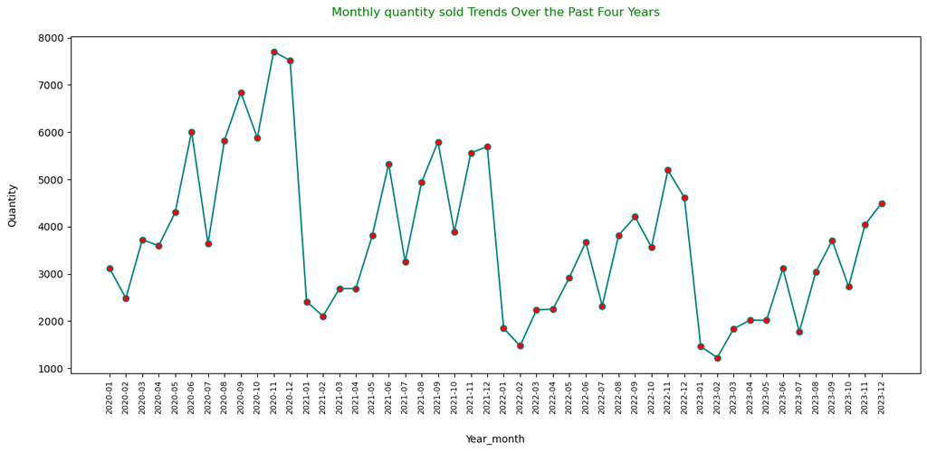

```python
#Monthly quantity sold Trends Over the Past Four Years

plt.figure(figsize=(15,6))
plt.plot(year_month_sales['year_month'],year_month_sales['quantity'],color='Teal',marker='o',markerfacecolor='red')
plt.xticks(rotation='vertical',size=8)

plt.xlabel('Year_month',labelpad=20)
plt.ylabel('Quantity',labelpad=20)
plt.title('Monthly quantity sold Trends Over the Past Four Years',pad=20,color='Green')
plt.show()
```

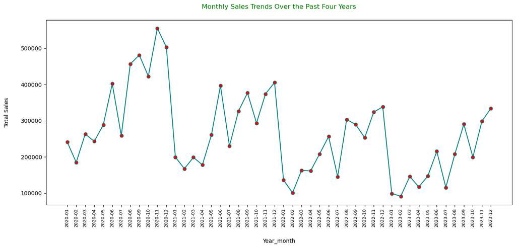

```python
plt.figure(figsize=(15,6))
plt.plot(year_month_sales['year_month'],year_month_sales['sales'],color='Teal',marker='o',markerfacecolor='red')
plt.xticks(rotation='vertical',size=8)

plt.xlabel('Year_month',labelpad=20)
plt.ylabel('Total Sales',labelpad=20)
plt.title('Monthly Sales Trends Over the Past Four Years',pad=20,color='Green')

plt.show()
```

From the graph, it's evident that the initial two months of each year exhibit a decline in sales and a significant decline in the sales trend during the month of July.

Yearly sales distribution across regions :

```python
country_sales=df.groupby(['region', df['order_date'].dt.year])[['sales','quantity']].sum()
```

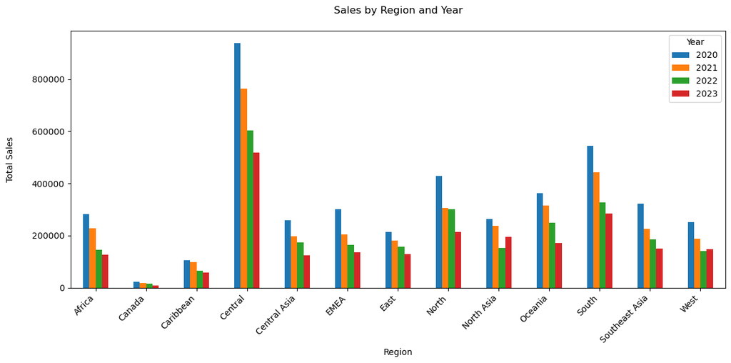

```python
#here why we dropping means Dropping the 'level_0' column in a single line ensures the DataFrame remains concise and
# devoid of redundant index-related columns after resetting the index.
country_sales = country_sales.drop(columns=['level_0'], errors='ignore').reset_index()

pivot_sales = country_sales.pivot(index='region', columns='order_date', values='sales')

pivot_sales.plot(kind='bar', figsize=(12, 6))
plt.title('Sales by Region and Year',pad=20)
plt.xlabel('Region')
plt.ylabel('Total Sales',labelpad=20)
plt.xticks(rotation=45, ha='right')
plt.legend(title='Year', bbox_to_anchor=(1, 1))
plt.tight_layout()
plt.show()
```

```python
canada_sales=df[df['region']=='Canada'].groupby('product_name')['sales'].sum().sort_values(ascending=False)
canada_sales.head(50)
```

```
product_name
Motorola Smart Phone, Full Size                3864
Hewlett Wireless Fax, High-Speed               3784
Breville Microwave, White                      1799
Safco Classic Bookcase, Pine                   1758
Rogers File Cart, Single Width                 1705
SanDisk Router, USB                            1539
Rogers Lockers, Industrial                     1484
Hon Swivel Stool, Black                        1289
Rogers Lockers, Single Width                   1270
Hamilton Beach Stove, Red                      1085
Hamilton Beach Stove, Black                    1084
Motorola Audio Dock, Full Size                 1048
StarTech Inkjet, Durable                        900
Fellowes Lockers, Blue                          829
SanDisk Router, Erganomic                       762
Ikea Stackable Bookrack, Pine                   744
Ikea Stackable Bookrack, Traditional            735
Bush Floating Shelf Set, Mobile                 695
Tenex File Cart, Single Width                   672
Cisco Smart Phone, with Caller ID               654
Hoover Microwave, Red                           617
Cisco Signal Booster, VoIP                      608
StarTech Inkjet, Wireless                       604
Brother Ink, Digital                            588
KitchenAid Stove, Red                           570
Binney & Smith Canvas, Blue                     565
Cuisinart Microwave, Silver                     558
Samsung Signal Booster, Cordless                558
Fellowes File Cart, Industrial                  551
Bevis Wood Table, with Bottom Storage           534
Panasonic Printer, White                        530
Canon Copy Machine, Color                       527
Hoover Refrigerator, Black                      526
Brother Copy Machine, Color                     521
Apple Audio Dock, Full Size                     504
Apple Speaker Phone, with Caller ID             493
Hon Executive Leather Armchair, Adjustable      460
Belkin Memory Card, USB                         460
Breville Toaster, Black                         457
Tenex Lockers, Industrial                       409
Panasonic Calculator, White                     390
Hewlett Fax and Copier, Color                   389
Canon Fax and Copier, Color                     386
Eldon File Cart, Industrial                     384
SanDisk Computer Printout Paper, Multicolor     374
Cisco Audio Dock, Cordless                      370
Harbour Creations Swivel Stool, Adjustable      365
Cisco Audio Dock, with Caller ID                364
Okidata Card Printer, Durable                   352
Hewlett Fax Machine, Laser                      320
Name: sales, dtype: int64
```

```python
canada_sales=df[df['region']=='Canada'].groupby('product_name')['sales'].sum().sort_values(ascending=False)
canada_sales.tail(50)
```

```
product_name
Avery Index Tab, Durable                                            20
Stockwell Clamps, Bulk Pack                                         19
Fellowes Box, Wire Frame                                            19
Avery File Folder Labels, 5000 Label Set                            19
Smead Folders, Industrial                                           18
Smead Folders, Single Width                                         18
Cardinal Index Tab, Economy                                         18
Acco Hole Reinforcements, Clear                                     18
Ames Business Envelopes, Set of 50                                  18
SanDisk Parchment Paper, Premium                                    17
OIC Rubber Bands, Bulk Pack                                         17
BIC Pens, Water Color                                               17
Advantus Rubber Bands, Metal                                        17
OIC Rubber Bands, Metal                                             17
Stockwell Clamps, Assorted Sizes                                    16
Sanford Highlighters, Blue                                          16
Kraft Clasp Envelope, Recycled                                      16
Eldon Folders, Wire Frame                                           16
Boston Pens, Fluorescent                                            15
Advantus Push Pins, 12 Pack                                         14
Kleencut Ruler, High Speed                                          14
Ibico Binder Covers, Recycled                                       14
Ibico Binder Covers, Economy                                        14
Novimex Round Labels, Laser Printer Compatible                      13
Cardinal Binder, Clear                                              13
Stockwell Paper Clips, Metal                                        13
Avery Binder, Economy                                               13
Binney & Smith Pens, Fluorescent                                    13
OIC Push Pins, Assorted Sizes                                       12
Wilson Jones Hole Reinforcements, Clear                             12
Hon Shipping Labels, 5000 Label Set                                 12
Avery Binder, Clear                                                 12
Stockwell Push Pins, Assorted Sizes                                 11
Cardinal Binder Covers, Clear                                       11
Harbour Creations Legal Exhibit Labels, Laser Printer Compatible    11
Stockwell Paper Clips, Assorted Sizes                               11
Advantus Staples, 12 Pack                                           10
Hon Round Labels, Adjustable                                         9
Avery Legal Exhibit Labels, Adjustable                               9
Harbour Creations Legal Exhibit Labels, Adjustable                   9
Eldon Box, Wire Frame                                                9
Ibico Index Tab, Durable                                             9
Smead Removable Labels, Adjustable                                   8
Acco Hole Reinforcements, Economy                                    7
Ibico Hole Reinforcements, Economy                                   7
Hon Round Labels, Alphabetical                                       6
Wilson Jones Index Tab, Clear                                        6
Smead Round Labels, Adjustable                                       5
Wilson Jones Hole Reinforcements, Economy                            5
Novimex Round Labels, Adjustable                                     4
Name: sales, dtype: int64
```

```python
canada_sales=df[df['region']=='Canada'].groupby('sub_category')[['quantity','sales','profit']].sum().sort_values(by='quantity',ascending=False)
canada_sales.head(50)
```

| sub_category | quantity | sales | profit |
| --- | --- | --- | --- |
| Binders | 132 | 3091 | 786.18 |
| Art | 129 | 4121 | 913.35 |
| Storage | 118 | 10586 | 2912.43 |
| Paper | 54 | 1520 | 373.86 |
| Labels | 49 | 423 | 129.33 |
| Phones | 46 | 10086 | 2679.87 |
| Accessories | 42 | 4472 | 1295.31 |
| Supplies | 41 | 1310 | 297.09 |
| Fasteners | 35 | 478 | 140.13 |
| Bookcases | 32 | 5734 | 1342.53 |
| Appliances | 30 | 7941 | 2233.98 |
| Copiers | 29 | 7467 | 2663.64 |
| Machines | 25 | 4275 | 607.80 |
| Envelopes | 25 | 567 | 171.18 |
| Chairs | 24 | 3202 | 856.74 |
| Furnishings | 20 | 809 | 113.79 |
| Tables | 2 | 850 | 300.18 |

Over the years, the Central region has been the primary contributor to the company's total sales, while Canada has consistently made the smallest contribution. Furthermore, the overall sales trend indicates a decline, signifying a decrease in sales over time

TOP SELLING PRODUCTS :

```python
result = df.groupby('product_name').agg({'sales': 'sum', 'category': 'first'}).reset_index().sort_values(by='sales', ascending=False).head(15)
result
```

|  | product_name | sales | category |
| --- | --- | --- | --- |
| 310 | Apple Smart Phone, Full Size | 86936 | Technology |
| 970 | Cisco Smart Phone, Full Size | 76441 | Technology |
| 2415 | Motorola Smart Phone, Full Size | 73159 | Technology |
| 2501 | Nokia Smart Phone, Full Size | 71904 | Technology |
| 866 | Canon imageCLASS 2200 Advanced Copier | 61600 | Technology |
| 1837 | Hon Executive Leather Armchair, Adjustable | 58200 | Furniture |
| 2631 | Office Star Executive Leather Armchair, Adjust... | 50667 | Furniture |
| 1714 | Harbour Creations Executive Leather Armchair, ... | 50120 | Furniture |
| 2988 | Samsung Smart Phone, Cordless | 48654 | Technology |
| 2502 | Nokia Smart Phone, with Caller ID | 47880 | Technology |
| 2990 | Samsung Smart Phone, VoIP | 45406 | Technology |
| 971 | Cisco Smart Phone, with Caller ID | 43124 | Technology |
| 2903 | SAFCO Executive Leather Armchair, Black | 41921 | Furniture |
| 969 | Cisco Smart Phone, Cordless | 41021 | Technology |
| 2524 | Novimex Executive Leather Armchair, Adjustable | 40586 | Furniture |

Top 10 products based on sales for each year:

```python
df['order_year'] = df['order_date'].dt.year

result = df.groupby(['order_year', 'product_name','product_id']).agg({'sales': 'sum', 'category': 'first'}).reset_index()

# Group by year, sort sales, and select top 15 products for each year
result = result.groupby('order_year').apply(lambda x: x.nlargest(10, 'sales')).reset_index(drop=True)
result
```

|  | order_year | product_name | product_id | sales | category |
| --- | --- | --- | --- | --- | --- |
| 0 | 2020 | Canon imageCLASS 2200 Advanced Copier | TEC-CO-10004722 | 35700 | Technology |
| 1 | 2020 | Martin Yale Chadless Opener Electric Letter Op... | OFF-SU-10002881 | 11826 | Office Supplies |
| 2 | 2020 | Apple Smart Phone, Cordless | TEC-PH-10002683 | 10969 | Technology |
| 3 | 2020 | GBC DocuBind TL300 Electric Binding System | OFF-BI-10001359 | 10944 | Office Supplies |
| 4 | 2020 | Novimex Executive Leather Armchair, Red | FUR-CH-10000602 | 9826 | Furniture |
| 5 | 2020 | Sauder Classic Bookcase, Traditional | FUR-BO-10004852 | 9679 | Furniture |
| 6 | 2020 | Hoover Stove, Red | OFF-AP-10004512 | 9608 | Office Supplies |
| 7 | 2020 | Breville Refrigerator, White | OFF-AP-10002244 | 9532 | Office Supplies |
| 8 | 2020 | Motorola Smart Phone, Full Size | TEC-MOT-10000554 | 9273 | Technology |
| 9 | 2020 | Hewlett Packard LaserJet 3310 Copier | TEC-CO-10001449 | 9240 | Technology |
| 10 | 2021 | Canon imageCLASS 2200 Advanced Copier | TEC-CO-10004722 | 25900 | Technology |
| 11 | 2021 | GBC Ibimaster 500 Manual ProClick Binding System | OFF-BI-10000545 | 12861 | Office Supplies |
| 12 | 2021 | 3D Systems Cube Printer, 2nd Generation, Magenta | TEC-MA-10001047 | 9100 | Technology |
| 13 | 2021 | High Speed Automatic Electric Letter Opener | OFF-SU-10000151 | 8843 | Office Supplies |
| 14 | 2021 | HP Designjet T520 Inkjet Large Format Printer ... | TEC-MA-10001127 | 8750 | Technology |
| 15 | 2021 | Nokia Smart Phone, with Caller ID | TEC-PH-10004664 | 8357 | Technology |
| 16 | 2021 | KitchenAid Refrigerator, Black | OFF-AP-10003590 | 7911 | Office Supplies |
| 17 | 2021 | Okidata MB760 Printer | TEC-MA-10000984 | 7835 | Technology |
| 18 | 2021 | Motorola Smart Phone, Full Size | TEC-PH-10002962 | 7728 | Technology |
| 19 | 2021 | Hon Executive Leather Armchair, Adjustable | FUR-CH-10003581 | 7349 | Furniture |
| 20 | 2022 | Fellowes PB500 Electric Punch Plastic Comb Bin... | OFF-BI-10003527 | 15760 | Office Supplies |
| 21 | 2022 | Riverside Palais Royal Lawyers Bookcase, Royal... | FUR-BO-10004834 | 11717 | Furniture |
| 22 | 2022 | Nokia Smart Phone, Full Size | TEC-PH-10004823 | 10972 | Technology |
| 23 | 2022 | Apple Smart Phone, Full Size | TEC-PH-10001457 | 10647 | Technology |
| 24 | 2022 | Hon Executive Leather Armchair, Black | FUR-CH-10002213 | 8955 | Furniture |
| 25 | 2022 | Nokia Smart Phone, with Caller ID | TEC-PH-10004664 | 8459 | Technology |
| 26 | 2022 | Novimex Executive Leather Armchair, Adjustable | FUR-CH-10000660 | 7790 | Furniture |
| 27 | 2022 | Motorola Smart Phone, Cordless | TEC-PH-10004583 | 7424 | Technology |
| 28 | 2022 | Barricks Training Table, Adjustable Height | FUR-BAR-10002449 | 7051 | Furniture |
| 29 | 2022 | Zebra ZM400 Thermal Label Printer | TEC-MA-10000045 | 6966 | Technology |
| 30 | 2023 | Cisco TelePresence System EX90 Videoconferenci... | TEC-MA-10002412 | 22638 | Technology |
| 31 | 2023 | Lexmark MX611dhe Monochrome Laser Printer | TEC-MA-10000822 | 11220 | Technology |
| 32 | 2023 | Nokia Smart Phone, with Caller ID | TEC-PH-10004664 | 10031 | Technology |
| 33 | 2023 | HP Designjet T520 Inkjet Large Format Printer ... | TEC-MA-10001127 | 9625 | Technology |
| 34 | 2023 | Samsung Smart Phone, Cordless | TEC-PH-10001751 | 9572 | Technology |
| 35 | 2023 | Samsung Smart Phone, VoIP | TEC-PH-10000303 | 9544 | Technology |
| 36 | 2023 | Ibico EPK-21 Electric Binding System | OFF-BI-10001120 | 9450 | Office Supplies |
| 37 | 2023 | High Speed Automatic Electric Letter Opener | OFF-SU-10000151 | 8188 | Office Supplies |
| 38 | 2023 | Office Star Executive Leather Armchair, Black | FUR-CH-10002250 | 7693 | Furniture |
| 39 | 2023 | Nokia Smart Phone, Cordless | TEC-PH-10003713 | 6679 | Technology |

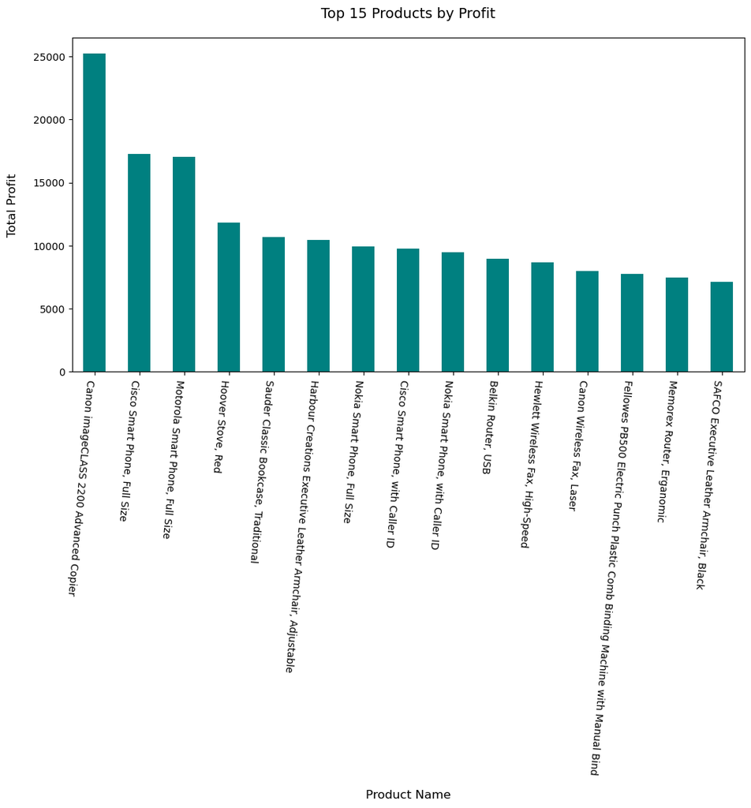

```python
top15_products=df.groupby('product_name')['profit'].sum().sort_values(ascending=False).head(15)


plt.figure(figsize=(12, 6))
top15_products.plot(kind='bar', color='teal')

# Set chart title and labels
plt.title('Top 15 Products by Profit', fontsize=14, pad=20)  # Adjust title padding
plt.xlabel('Product Name', fontsize=12, labelpad=15)  # Custom label for x-axis with labelpad
plt.ylabel('Total Profit', fontsize=12, labelpad=15)  # Custom label for y-axis with labelpad
plt.xticks(rotation=-95, ha='right')  # Rotate x-axis labels for better readability

# Show plot
plt.tight_layout()
plt.show()
```

```python
result[result['category'] == 'Technology'].groupby('order_year')['category'].value_counts()
```

```
order_year  category
2020        Technology    4
2021        Technology    6
2022        Technology    5
2023        Technology    7
Name: count, dtype: int64
```

The Nokia Smart Phone with Caller ID, identified by the product ID (TEC-PH-10004664), has shown substantial performance growth from 2021 to 2023, with increasing demand observed each year. Offering a reasonable discount on this product is expected to lead to a boost in both sales volume and revenue.

Regionwise top selling process

```python
# Group by both year and product_name, then compute sum of sales and pick the first category
result = df.groupby(['state', 'product_name','region']).agg({'sales': 'sum', 'category': 'first'}).reset_index()

# Group by year, sort sales, and select top 15 products for each year
result = result.groupby('state').apply(lambda x: x.nlargest(1, 'sales')).reset_index(drop=True).sort_values(by='sales',ascending=False)

result.head(20)
```

|  | state | product_name | region | sales | category |
| --- | --- | --- | --- | --- | --- |
| 334 | Florida | Cisco TelePresence System EX90 Videoconferenci... | South | 22638 | Technology |
| 441 | Indiana | Canon imageCLASS 2200 Advanced Copier | Central | 17500 | Technology |
| 313 | England | Nokia Smart Phone, Full Size | North | 16807 | Technology |
| 1052 | Washington | Canon imageCLASS 2200 Advanced Copier | West | 14000 | Technology |
| 822 | Queensland | Nokia Smart Phone, with Caller ID | Oceania | 13225 | Technology |
| 194 | California | High Speed Automatic Electric Letter Opener | West | 13101 | Office Supplies |
| 985 | Texas | Lexmark MX611dhe Monochrome Laser Printer | Central | 11220 | Technology |
| 705 | New York | Canon imageCLASS 2200 Advanced Copier | East | 11200 | Technology |
| 286 | Distrito Federal | Cisco Smart Phone, Full Size | North | 10871 | Technology |
| 275 | Delaware | Canon imageCLASS 2200 Advanced Copier | East | 10500 | Technology |
| 648 | Michigan | GBC Ibimaster 500 Manual ProClick Binding System | Central | 9893 | Office Supplies |
| 653 | Minnesota | Ibico EPK-21 Electric Binding System | Central | 9450 | Office Supplies |
| 702 | New Jersey | 3D Systems Cube Printer, 2nd Generation, Magenta | East | 9100 | Technology |
| 1040 | Virginia | HP Designjet T520 Inkjet Large Format Printer ... | South | 8750 | Technology |
| 779 | Pennsylvania | Canon imageCLASS 2200 Advanced Copier | East | 8400 | Technology |
| 720 | North Carolina | Cubify CubeX 3D Printer Triple Head Print | South | 8000 | Technology |
| 1005 | Tuscany | Hoover Stove, Red | South | 7959 | Office Supplies |
| 704 | New South Wales | Novimex Executive Leather Armchair, Black | Oceania | 7830 | Furniture |
| 354 | Georgia | Fellowes PB500 Electric Punch Plastic Comb Bin... | South | 7626 | Office Supplies |
| 901 | Shizuoka | Samsung Smart Phone, VoIP | North Asia | 6999 | Technology |

Statewise sales

```python
#top 20 states with highest sales

df.groupby('state')[['sales']].sum().sort_values(by='sales',ascending=False).head(20)
```

| state | sales |
| --- | --- |
| England | 485166 |
| California | 457731 |
| Ile-de-France | 317818 |
| New York | 310914 |
| New South Wales | 270513 |
| Queensland | 238311 |
| North Rhine-Westphalia | 216458 |
| Texas | 170187 |
| San Salvador | 153648 |
| National Capital | 152185 |
| Victoria | 151788 |
| Washington | 138656 |
| Distrito Federal | 128428 |
| Pennsylvania | 116522 |
| Provence-Alpes-Côte d'Azur | 114368 |
| Western Australia | 111084 |
| Guatemala | 103650 |
| Maharashtra | 101325 |
| São Paulo | 98418 |
| Guangdong | 96096 |

```python
#bottom 20 states with low sales

df.groupby('state')['sales'].sum().sort_values(ascending=False).tail(20)
```

```
state
Central Jutland       34
Ebonyi                34
Táchira               33
Lambayeque            32
Nagano                31
Caras-Severin         29
Tottori               27
Kastamonu             26
Osjecko-Baranjska     25
Inhambane             23
Casanare              23
Gangwon               22
Zhambyl               22
Edirne                19
Rize                  19
Pernik                15
Manicaland            12
Bitola                11
Kabarole               4
Matabeleland North     3
Name: sales, dtype: int64
```

datewise sales trend

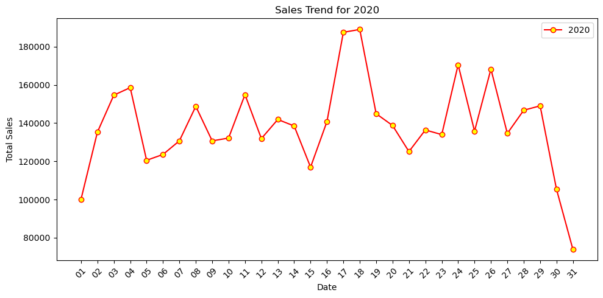

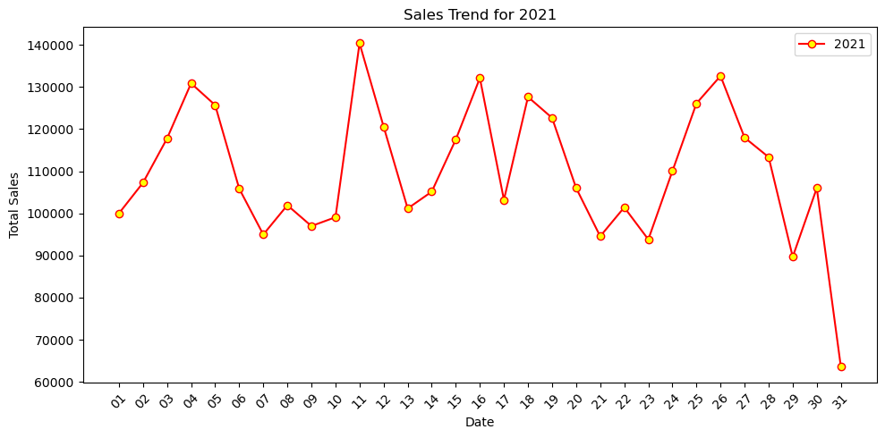

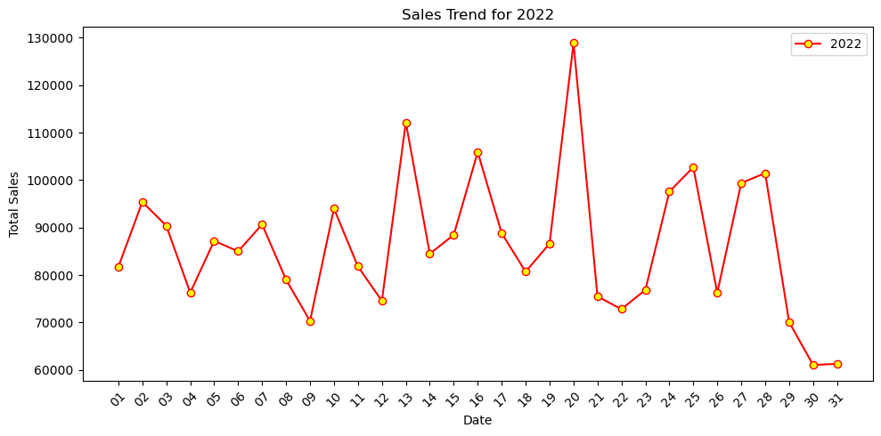

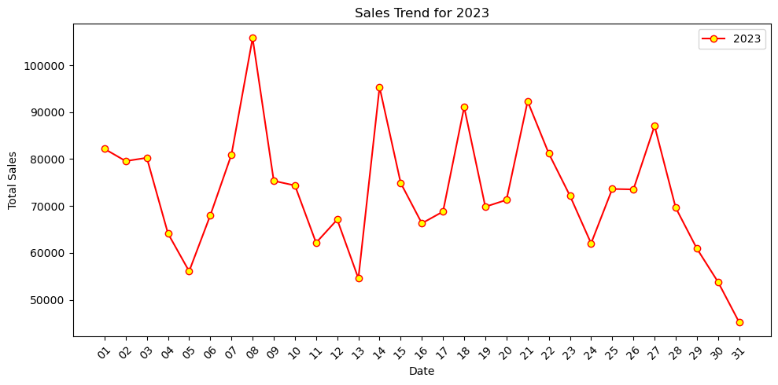

```python
# Group data by year and day, and calculate total sales for each day
yearly_daily_sales = df.groupby([df['order_date'].dt.year, df['order_date'].dt.strftime('%d')])['sales'].sum()

# Plot each year's sales trend on a date-wise basis
for year, sales_data in yearly_daily_sales.groupby(level=0):
    plt.figure(figsize=(10, 5))
    plt.plot(sales_data.index.get_level_values(1), sales_data.values, label=str(year),color='red',marker='o',markerfacecolor='yellow')
    plt.title(f'Sales Trend for {year}')
    plt.xlabel('Date')
    plt.ylabel('Total Sales')
    plt.xticks(rotation=45)
    plt.legend()
    plt.tight_layout()
    plt.show()
```

In the chart, there is a noticeable drop in sales during the final two days of each month.

SALES VS DISCOUNT

```python
correlation = df["discount"].corr(df["sales"])
correlation
```

```
-0.0867280828191381
```

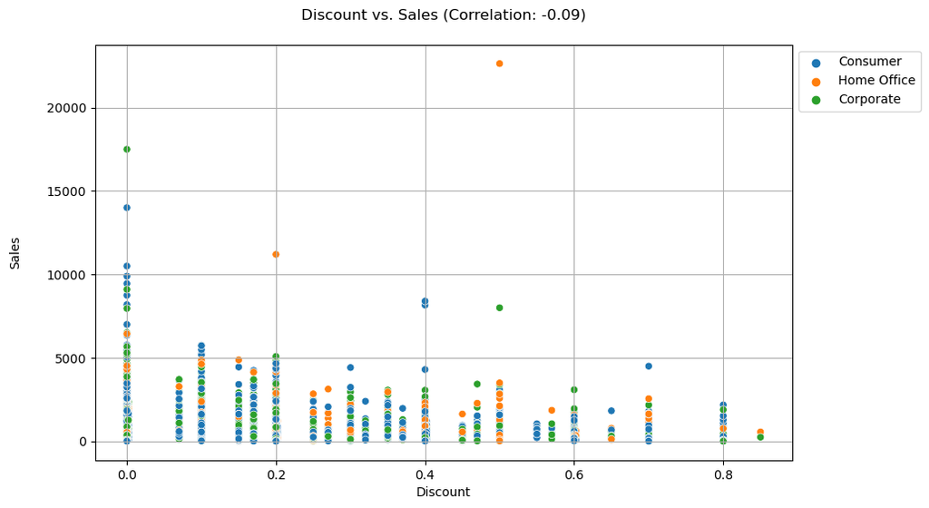

```python
#using scatter plot to see any trend/correlation between discount and sales

plt.figure(figsize=(10, 6))
sns.scatterplot(x="discount", y="sales", data=df, hue="segment")
plt.title(f"Discount vs. Sales (Correlation: {correlation:.2f})",pad=20)
plt.xlabel("Discount")
plt.ylabel("Sales",labelpad=20)
plt.legend(bbox_to_anchor=(1, 1), loc='upper left')
plt.grid(True)
plt.show()
```

Based on the data,there is no significant influence of discounts on sales for the various sub-categories. The weak negative correlation suggests that changes in discounts do not strongly impact sales.From above,we can conclude that there is no direct influence of discount on sales.

```python
correlation_q = df["shipping_cost"].corr(df["quantity"])
correlation_q
```

```
0.27264897337673216
```

```python
correlation_s = df["shipping_cost"].corr(df["profit"])
correlation_s
```

```
0.35703337043993444
```

```python
correlation_s = df["quantity"].corr(df["sales"])
correlation_s
```

```
0.31358025141675827
```

```python
correlation_p = df["quantity"].corr(df["profit"])
correlation_p
```

```
0.10474270359129863
```

[figure not shown]

```python
plt.figure(figsize=(10, 6))
sns.scatterplot(x="quantity", y="profit", data=df, hue="category")
plt.title(f"quantity vs. profit (Correlation: {correlation_p:.2f})",pad=20)
plt.xlabel("quantity")
plt.ylabel("Sales",labelpad=20)
plt.legend(bbox_to_anchor=(1, 1), loc='upper left')
plt.grid(True)
plt.show()
```

percentage contribution of each category to total profit :

```python
category_profit = df.groupby('category')['profit'].sum().reset_index().sort_values(by='profit',ascending=False)

total_profit = category_profit['profit'].sum()

# Calculate percentage contribution of each category to total sales
category_profit['Contribution_Percentage'] = (category_profit['profit'] / total_profit) * 100

print("Category-wise Profit:")
print(category_profit)
print("\nTotal Profit: ", total_profit)
```

```
Category-wise Profit:
          category        profit  Contribution_Percentage
2       Technology  663778.73378                45.184683
1  Office Supplies  518473.83430                35.293502
0        Furniture  286782.25380                19.521815

Total Profit:  1469034.8218800002
```

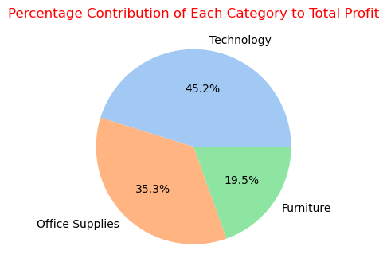

```python
colors = sns.color_palette('pastel')

category_sales_sorted = category_profit.sort_values(by='Contribution_Percentage', ascending=False)

plt.figure(figsize=(6, 3.5))

plt.pie(category_sales_sorted['Contribution_Percentage'], labels=category_sales_sorted['category'], autopct='%1.1f%%',  colors=colors)

plt.title('Percentage Contribution of Each Category to Total Profit', pad=20, color='red')
plt.axis('equal')
plt.show()
```

```python
#percentage contribution of each segment to total sales
segment_sales = df.groupby('segment')['sales'].sum().reset_index()

# Calculate total sales
total_sales = segment_sales['sales'].sum()

# Calculate percentage contribution of each category to total sales
segment_sales['Contribution_Percentage'] = (segment_sales['sales'] / total_sales) * 100

print("Segment-wise Sales:")
print(segment_sales)
print("\nTotal Sales: ", total_sales)
```

```
Segment-wise Sales:
       segment    sales  Contribution_Percentage
0     Consumer  6508145                51.476618
1    Corporate  3824808                30.252580
2  Home Office  2309962                18.270802

Total Sales:  12642915
```

[figure not shown]

```python
colors = sns.color_palette('pastel')

plt.figure(figsize=(6, 3.5))

plt.pie(segment_sales['Contribution_Percentage'], labels=segment_sales['segment'], autopct='%1.1f%%',  colors=colors)

plt.title('Percentage Contribution of Each Segment to Total Profit', pad=20, color='red')

plt.axis('equal')
plt.show()
```

SHIPPING EDA:

```python
ship_mode_groupby = df.groupby('ship_mode')['sales'].count().sort_values(ascending=False)
total_sales = df['sales'].count()

# Calculate percentage contribution
percentage_contribution = (ship_mode_groupby / total_sales) * 100

# Create a DataFrame from ship_mode_groupby and percentage_contribution
result_df = pd.DataFrame({'Number of Sales': ship_mode_groupby, 'Percentage Contribution': percentage_contribution})

print(result_df)
print("\n")
print("Total sales :", total_sales)
```

```
                Number of Sales  Percentage Contribution
ship_mode
Standard Class            30775                60.001950
Second Class              10309                20.099435
First Class                7505                14.632482
Same Day                   2701                 5.266134


Total sales : 51290
```

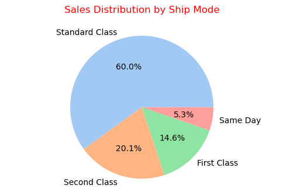

```python
# Plotting
plt.figure(figsize=(6, 3.5))

plt.pie(result_df['Number of Sales'], labels=result_df.index, autopct='%1.1f%%',colors=colors)

plt.title('Sales Distribution by Ship Mode',pad=20,color='red')

plt.axis('equal')

# Show plot
plt.show()
```

Standard Class is the dominant shipping mode, contributing approximately 60% of the total sales. This suggests that customers prioritize affordability over speed in most cases.

```python
ship_mode_groupby = df.groupby(['segment','ship_mode'])['sales'].count()
ship_mode_groupby
```

```
segment      ship_mode
Consumer     First Class        3918
             Same Day           1467
             Second Class       5257
             Standard Class    15876
Corporate    First Class        2245
             Same Day            728
             Second Class       3198
             Standard Class     9258
Home Office  First Class        1342
             Same Day            506
             Second Class       1854
             Standard Class     5641
Name: sales, dtype: int64
```

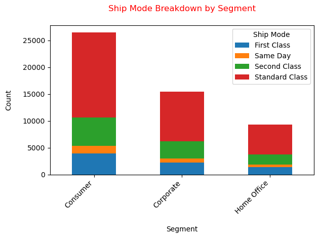

```python
ship_mode_groupby_df = ship_mode_groupby.unstack().fillna(0)


plt.figure(figsize=(10, 6))

ship_mode_groupby_df.plot(kind='bar', stacked=True)

plt.title('Ship Mode Breakdown by Segment', pad=20, color='red')
plt.xlabel('Segment', labelpad=15)
plt.ylabel('Count', labelpad=15)
plt.xticks(rotation=45, ha='right')  # Rotate x-axis labels for better readability

plt.legend(title='Ship Mode')
plt.tight_layout()
plt.show()
```

In consumer segment,Higher proportion of Same Day compared to the other segments, suggesting a greater willingness to pay for faster delivery.While Standard Class dominates, there are variations in preferences between segments

Recommedation:  
1.Tailor promotions based on segment preferences. Highlight premium services for corporate clients and convenience for home office users.  
2.Educate customers about the benefits of different ship modes.  
3.Gather feedback from each segment to continuously improve shipping services.</span>

Returns:

```python
returns=df[df['Returned']=='Yes'].groupby('sub_category')['Returned'].count().sort_values(ascending=False)
print(returns)

total_returns=returns.sum()
print("Total returns :",total_returns)
```

```
sub_category
Binders        339
Storage        252
Paper          240
Chairs         223
Art            222
Accessories    219
Furnishings    202
Phones         198
Fasteners      177
Envelopes      146
Bookcases      146
Labels         145
Supplies       142
Copiers        135
Appliances     125
Machines        72
Tables          67
Name: Returned, dtype: int64
Total returns : 3050
```

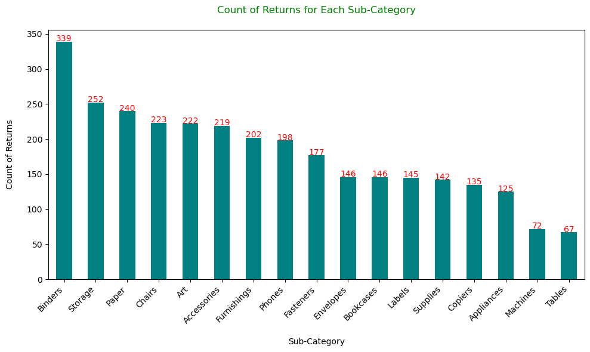

```python
plt.figure(figsize=(10, 6))

# Create bar chart with light purple color
returns.plot(kind='bar', color='teal')

# Add data labels to each bar with a decent gap
gap = 0.5  # Adjust this value to set the gap
for i, count in enumerate(returns):
    plt.text(i, count + gap, str(count), ha='center',color='red')

# Add a title and labels
plt.title('Count of Returns for Each Sub-Category', pad=20, color='green')
plt.xlabel('Sub-Category', labelpad=15)
plt.ylabel('Count of Returns', labelpad=15)
plt.xticks(rotation=45, ha='right')  # Rotate x-axis labels for better readability

# Show plot
plt.tight_layout()
plt.show()
```

Binders sub-category has the most highest returns takesn place.High return counts in certain categories might indicate potential issues with product quality, customer satisfaction, or fulfillment processes in those categories. This could warrant further investigation into the reasons behind the returns and strategies for improvement.

Recommendation:  
1.Strengthen quality control processes for high-return sub-categories.  
2.Collect feedback from customers returning items. Identify common issues and address them.Use return data and feedback to enhance product design, materials, and functionality.

By understanding return patterns and addressing underlying issues, businesses can mitigate these costs and improve overall profitability. </span>

Most Profitable Category

```python
df.groupby('category')['profit'].sum().sort_values(ascending=False)
```

```
category
Technology         663778.73378
Office Supplies    518473.83430
Furniture          286782.25380
Name: profit, dtype: float64
```

```python
df.groupby('sub_category')['profit'].sum().sort_values(ascending=False)
```

```
sub_category
Copiers        258567.54878
Phones         216717.00580
Bookcases      161924.41950
Chairs         141973.79750
Appliances     141680.58940
Accessories    129626.30620
Storage        108461.48980
Binders         72449.84600
Paper           59207.68270
Machines        58867.87300
Art             57953.91090
Furnishings     46967.42550
Envelopes       29601.11630
Supplies        22583.26310
Labels          15010.51200
Fasteners       11525.42410
Tables         -64083.38870
Name: profit, dtype: float64
```

Most Profitable Category Sub-categories such as Copiers, Phones, Bookcases, and Chairs appear to be the most profitable, compared to others. The 'Tables' sub-category is experiencing a negative profit margin, indicating that the business is incurring losses from selling tables.

Recommedation:  
1.Identify and address cost inefficiencies in less profitable sub-categories to improve overall profitability.  
2.Monitor sub-category profitability over time to assess performance and make strategic adjustments as needed.